# B90V4

Rico Kronenberg, Lisa Marie Oehlschlägel

11 Mai 2018

### BROOK90 Version 4

With running the MainProg.R script all necessary scripts and variables are loaded. Starting the model requires to run the script B90V4.R from source.

This Code is modified for Version 4, June 3, 1999. The Symbol ^^ shows variables that are returned from or altered by subroutines (requires a fixed width font). There are intrinsic functions needed:

- CSNG
- INT
- INKEY$
- CHR$

### Contents

- Programm initialisations
- Parameter initializations
- Running the model
- Plotted data

### Programm initialisations

First the script of the main programm (MainProg.R) has to be uploaded to run the script of B90V4.R in R-Markdown.

The program initializations starts if it is New Run or Rerun. Settings for the time are done, like number of days per month, interval times and zeroed vectors are set. The Year dates are changed from two-digit year to four-digit. The DOY is set with the help of Function DOYF with the input DOM, MONTHN and DAYMO and number of days for february depending on leap year or not. The time step for precipitation interval is calculated and zero accumulators are called. Some neccesary values are calculated or unlisted from functions:

- initial values
- soil water parameters and initial variables
- initial soil water variables
- initial total water in system
- any initial snow has zero liquid water and cold content

```r
SCRIPTPATH<-"c:\\Users\\LM\\Documents\\BROOK90\\R_scripte\\"
source(file.path(SCRIPTPATH,"MainProg.R"))

if((runflag == 0) || (runflag == 1)){
  DAYMO[1] = 31
  DAYMO[2] = 28
  DAYMO[3] = 31
  DAYMO[4] = 30
  DAYMO[5] = 31
  DAYMO[6] = 30
  DAYMO[7] = 31
  DAYMO[8] = 31
  DAYMO[9] = 30
  DAYMO[10] = 31
  DAYMO[11] = 30
  DAYMO[12] = 31
    IDAY =1
    IInterValDay=1
    NDAYS=length(MData[[1]])
    NITSR = 0
    NITSY = 0
    NITSM = 0
    YEARN = as.numeric(MData[[1]][IDAY])

    daymax=NDAYS-IDAY+1
    maxF=0
    precc=rep(0,daymax)
    evpp=rep(0,daymax)
    floww=rep(0,daymax)
    rnett=rep(0,daymax)
    ptrann=rep(0,daymax)
    irvpp=rep(0,daymax)
    isvpp=rep(0,daymax)
    snoww=rep(0,daymax)
    swatt=rep(0,daymax)
    pintt=rep(0,daymax)
    snvpp=rep(0,daymax)
    slvpp=rep(0,daymax)
    trandd=rep(0,daymax)
    mesfld=rep(0,daymax)
    smltd=rep(0,daymax)
    slfld=rep(0,daymax)
    rfald=rep(0,daymax)
    sfald=rep(0,daymax)
    awatt=rep(0,daymax)
    adeff=rep(0,daymax)
    sintdd=rep(0,daymax)
    rintdd=rep(0,daymax)
    rthrd=rep(0,daymax)
    sthrd=rep(0,daymax)
    rsnod=rep(0,daymax)

    if( YEARN < 100){
        if(YEARN > 20){
            YEARN = YEARN + 1900
        }else{
            YEARN = YEARN + 2000
        }
    }
  MONTHN = as.numeric(MData[[2]][IDAY])
    DOM = as.numeric(MData[[3]][IDAY])
    DOY = DOY=DOYF(DOM,MONTHN,DAYMO)

      if (fnleap()) {
            DAYMO[2] = 29
        }else{
            DAYMO[2] = 28
        }
    if (SUBDAYDATA) {
    DTP = DT / NPINT
    }else{
        DTP = DT
    }
# zero accumulators
    zyear()
    zmonth()
# initial values
    SNOW = SNOWIN
    GWAT = GWATIN
    INTR = INTRIN
    INTS = INTSIN
    for( i in 1:NLAYER){
        PSIM[i] = PSIMIN[i]
    }
# soil water parameters and initial variables
    soilp<-SOILPAR()
      PSIG<-unlist(soilp[2])
      SWATMX<-unlist(soilp[3])
      WETF<-unlist(soilp[4])
      WETC<-unlist(soilp[5])
      CHM<-unlist(soilp[6])
      CHN<-unlist(soilp[7])
      WETNES<-unlist(soilp[8])
      SWATI<-unlist(soilp[9])
      KSAT<-unlist(soilp[10])
# ^^
# initial soil water variables
    soil<-SOILVAR()
      PSITI<-soil[1:ML]
      THETA<-soil[(ML+1):(2*ML)]
      KK<-soil[(2*ML+1):(3*ML)]
      SWAT<-soil[(3*ML+1)]
# ^^
# initial total water in system
    STORD = INTR + INTS + SNOW + SWAT + GWAT
    STORM = STORD
    STORY = STORD
# any initial snow has zero liquid water and cold content
    CC = 0
    SNOWLQ = 0
}
```

### Parameter initializations

Parameter initializations are done for New Run, Rerun and Continue Run. First some parameters are converted. Then the equivalent slope for radiation calculations is extracted with the help of Function EQUIVSLP. Other initialized parameters are:

- infiltration parameters
- source area parameters
- root density parameters

```r
# parameter conversions
GLMAX = GLMAXC / 100
GLMIN = GLMINC / 100
LAT = LATD / 57.296
ESLOPE = ESLOPED / 57.296
DSLOPE = DSLOPED / 57.296
ASPECT = ASPECTD / 57.296
# equivalent slope for radiation calculations
equi<-EQUIVSLP(LAT, ESLOPE, ASPECT)
  L1<-unlist(equi[1])
  L2<-unlist(equi[2])
# ^^
# infiltration parameters
infpa<-INFPAR(INFEXP, IDEPTH, NLAYER, THICK)
  ILAYER<-unlist(infpa[1])
  INFRAC<-unlist(infpa[2])
# ^^
# source area parameters
srfp<-SRFPAR(QDEPTH, NLAYER, THETAF, THICK, STONEF, SWATMX)
  QLAYER<-unlist(srfp[1])
  SWATQX<-unlist(srfp[2])
  SWATQF<-unlist(srfp[3])
# ^^
# root density parameters
RELDEN<-RTDEN(ROOTDEN, NLAYER, THICK)
```

### Running the model

After all initialization steps are done the model can be started. All important steps that are done are written in the following script as comments.

```r
while( IDAY <= NDAYS){
    NITSD = 0
        subdatafileline(IDAY)
  if( IDAY == INIDAYS + 1){
# end of initialization, reinitialize year and month accumulators
        STORD = INTR + INTS + SNOW + SWAT + GWAT
        STORM = STORD
        STORY = STORD
        NITSY = 0
        NITSM = 0
        zyear()
        zmonth()
  }
# calculate derived variables
    MSBSETVARS()
#
#* * * * *  B E G I N   D A Y - N I G H T   E T   L O O P  * * * * * * * * *
#potential and actual interception, evaporation, and transpiration
    MSBDAYNIGHT()
#
#* * * * * * * *  E N D   D A Y - N I G H T   L O O P  * * * * * * * * * *
# average rates over day
    PTRAN = (PTR[1] * DAYLEN + PTR[2] * (1 - DAYLEN)) / DT
    GEVP = (GER[1] * DAYLEN + GER[2] * (1 - DAYLEN)) / DT
    PINT = (PIR[1] * DAYLEN + PIR[2] * (1 - DAYLEN)) / DT
    GIVP = (GIR[1] * DAYLEN + GIR[2] * (1 - DAYLEN)) / DT
    for(i in 1:NLAYER){
        TRANI[i] = (ATRI[1, i] * DAYLEN + ATRI[2, i] * (1 - DAYLEN)) / DT
    }
# zero daily integrators
    zday()
#
#* * * * * * * * B E G I N   P R E C I P   I N T E R V A L * * * * * * * * *
for( N in 1:NPINT){
    if (SUBDAYDATA){
    subprfileline(IInterValDay)
      if (MESFLP <= -0.01) {MESFLP = MESFL / DT}
    }else{
# precip data from data file
        PREINT = PRECIN / DT
        MESFLP = MESFL / DT
    }
# interception and snow accumulation/melt
    MSBPREINT()
# initialize for iterations
# initial time remaining in iteration time step = precip time step
    DTRI = DTP
# initialize iteration counter
    NITS = 0
# zero precip interval integrators
    zpint()
#
#  *  *  *  *  *  *  B E G I N   I T E R A T I O N   *  *  *  *  *  *  *  *
while(!(DTRI <= 0)){
        NITS = NITS + 1
# check for events
        if (NITS %% 100 == 0) {}
# water movement through soil
        MSBITERATE()
# iteration calculations
# calculate SLFLI vertical macropore infiltration out of layer
        SLFLI[1] = SLFL - INFLI[1] - BYFLI[1]
        if (ILAYER >= 2){
          if (NLAYER >= ILAYER +1){
            for (i in 2:ILAYER){
            # does not execute if ILAYER% = 1 or 0
                SLFLI[i] = SLFLI[i - 1] - INFLI[i] - BYFLI[i]
            }
            for( i in (ILAYER + 1):NLAYER){
            # does not execute if NLAYER% < ILAYER% + 1
                SLFLI[i] = 0
            }
          }
        }
# integrate below ground storages over iteration interval
        for( i in 1:NLAYER){
            SWATI[i] = SWATI[i] + NTFLI[i] * DTI
        }
        GWAT = GWAT + (VRFLI[NLAYER] - GWFL - SEEP) * DTI
# new soil water variables and test for errors
        for (i in 1:NLAYER){
            swchek(i)
            WETNES[i] = SWATI[i] / SWATMX[i]
            PSIM[i] = FPSIMF(WETNES[i], PSIF[i], BEXP[i], WETINF[i], WETF[i], CHM[i], CHN[i])
        }
        soil<-SOILVAR()
           PSITI<-soil[1:ML]
           THETA<-soil[(ML+1):(2*ML)]
           KK<-soil[(2*ML+1):(3*ML)]
           SWAT<-soil[(3*ML+1)]
# ^^
# iteration output
# flows accumulated over precip interval
    paccum()
# time remaining in precipitation time-step
    DTRI = DTRI - DTI
    NITSR = NITSR + 1  # for visible display of iterations
}
#
#  *  *  *  *   E N D   i T E R A T I O N    L O O P  *  *  *  *  *  *  *  *
# display iterations
# integrate interception storages over precip interval
INTS = INTS + (SINT - ISVP) * DTP
INTR = INTR + (RINT - IRVP) * DTP
#  flows for precip interval summed from components
psum()
# precipitation interval output
# flows accumulated over day
daccum()
# accumulate iterations
  NITSD = NITSD + NITS
  NITSM = NITSM + NITS
  NITSY = NITSY + NITS
  IInterValDay<-IInterValDay+1
}
#
#* * * * *  E N D   P R E C I P   I N T E R V A L   L O O P  * * * * * * * *
# flows for day summed from components
dsum()
# check for water balance error
BALERD = STORD - (INTR + INTS + SNOW + SWAT + GWAT) + PRECD - EVAPD - FLOWD - SEEPD
STORD = INTR + INTS + SNOW + SWAT + GWAT
# flows accumulated over month
maccum()
# date checking on
if(DOM == DAYMO[MONTHN]){
# set up for next month
zmonth()
MONTHN = MONTHN + 1
DOM = 0
NITSM = 0
}  # for end of month
if (MONTHN == 13) {
# end of year
# set up for next year
  MONTHN = 1
  DOM = 1
  DOY = 1
  YEARN = YEARN + 1
  zyear()
  if (fnleap() ){
    DAYMO[2] = 29
  }else{
    DAYMO[2] = 28
  }
NITSY = 0
NITSM = 0
}
#set up for next day
IDAY = IDAY + 1
  MONTHN = as.numeric(MData[[2]][IDAY])
  DOM = as.numeric(MData[[3]][IDAY])
  YEARN = as.numeric(MData[[1]][IDAY])
  if(IDAY <= NDAYS)
  DOY=DOYF(DOM,MONTHN,DAYMO)

#* * * I N P U T   W E A T H E R   L I N E   F R O M   D F I L E * * *
#subdatafileline()
#
# ***************   E N D    D A Y   L O O P    **************************
    precc[daymax-NDAYS+IDAY-1]<-PRECD
    evpp[daymax-NDAYS+IDAY-1]<-EVAPD
    floww[daymax-NDAYS+IDAY-1]<-FLOWD
    rnett[daymax-NDAYS+IDAY-1]<-RNET
    irvpp[daymax-NDAYS+IDAY-1]<-IRVPD
    isvpp[daymax-NDAYS+IDAY-1]<-ISVPD
    ptrann[daymax-NDAYS+IDAY-1]<-PTRAND
    snoww[daymax-NDAYS+IDAY-1]<-SNOW
    swatt[daymax-NDAYS+IDAY-1]<-SWAT
    pintt[daymax-NDAYS+IDAY-1]<-PINTD
    snvpp[daymax-NDAYS+IDAY-1]<-SNVPD
    slvpp[daymax-NDAYS+IDAY-1]<-SLVPD
    trandd[daymax-NDAYS+IDAY-1]<-TRAND
    mesfld[daymax-NDAYS+IDAY-1]<-MESFLD
    smltd[daymax-NDAYS+IDAY-1]<-SMLTD
    slfld[daymax-NDAYS+IDAY-1]<-SLFLD
    rfald[daymax-NDAYS+IDAY-1]<-RFALD
    awatt[daymax-NDAYS+IDAY-1]<-AWAT
    adeff[daymax-NDAYS+IDAY-1]<-ADEF
    sintdd[daymax-NDAYS+IDAY-1]<-SINTD
    rintdd[daymax-NDAYS+IDAY-1]<-RINTD
    sfald[daymax-NDAYS+IDAY-1]<-SFALD
    rthrd[daymax-NDAYS+IDAY-1]<-RTHRD
    sthrd[daymax-NDAYS+IDAY-1]<-STHRD
    rsnod[daymax-NDAYS+IDAY-1]<-RSNOD
}
```

### Plotted data

At the end some data are plotted:

- precipitation - precc (points)
- evpp - evaporation (blue line)
- mesfld - measured flow (darkgreen line)
- floww - total flow (darkgreen line)

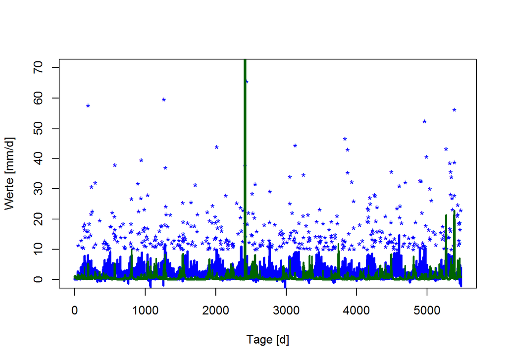

```r
plot(1:NDAYS,floww[1:NDAYS],col="red",type="l",lwd=3,ylim=c(0.0, 70),xlab="Tage [d]",ylab="Werte [mm/d]")

PrecBound<-10
points( which(precc %in% precc[precc>PrecBound]),precc[precc>PrecBound],col="blue",pch="*")
lines(1:NDAYS,evpp,col="blue",lwd=3)
lines(1:NDAYS,mesfld,col="darkgreen",lwd=2)
lines(1:NDAYS,floww,col="darkgreen",lwd=3)
```